### Landings

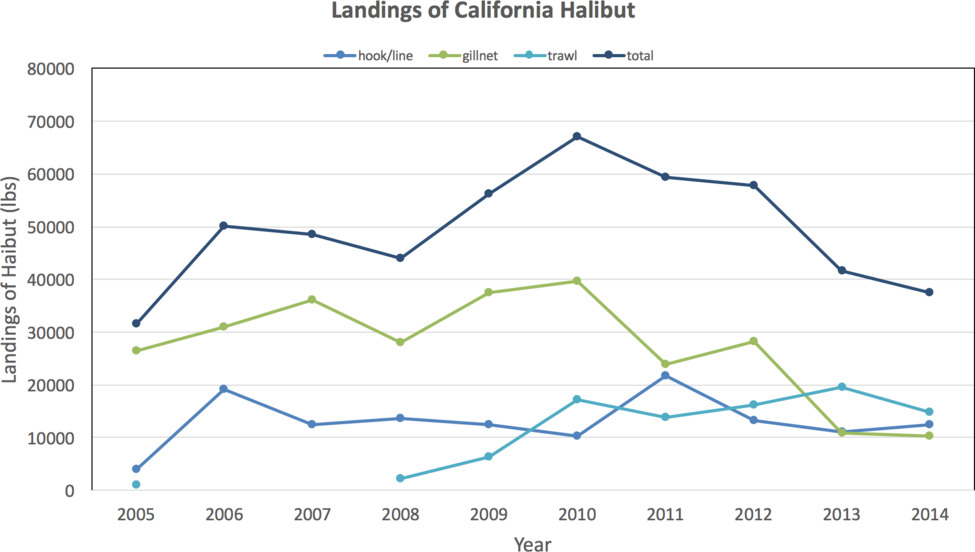

**Figure App.C.4.5a.**. A figure showing the pounds of California halibut landed by gear type in the commercial fleet from 2005 - 2014.

**Click for Details**

Landings of California halibut (*Paralichthys californicus*) in blocks around Channel Islands National Marine Sanctuary by hook/line (blue), gillnet (green), and trawl (teal) fishing gear. Landings data from the Santa Barbara port complex (Santa Barbara, Ventura, Oxnard, and Port Hueneme) and reflect take from the Fish and Game blocks 683–691, 706-714, 744, 745, 764, and 765 (see Figure App.C4.3 for map of blocks). Data source: CDFW; Figure: NOAA

### Vessels

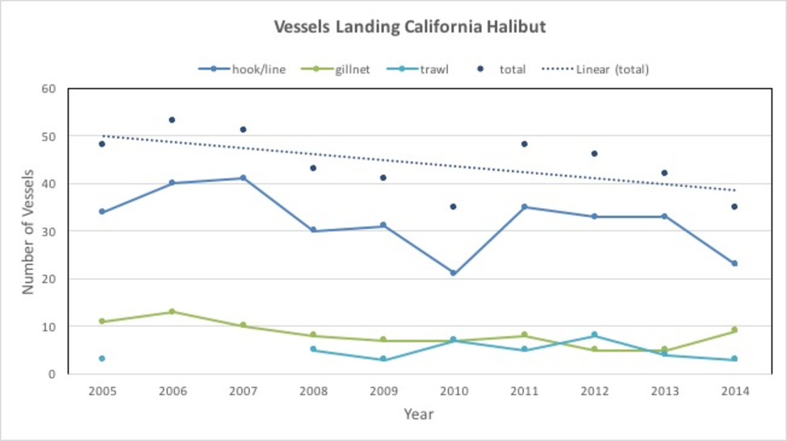

**Figure App.C.4.5b.**. A figure showing the number of fishing vessels (and gear types used) in the California halibut fishing fleet from 2005 - 2014.

**Click for Details**

The number of vessels fishing for California halibut (*Paralichthys californicus*) in blocks around Channel Islands National Marine Sanctuary by hook/line (blue), gillnet (green), and trawl (teal) fishing gear. Landings data from the Santa Barbara port complex (Santa Barbara, Ventura, Oxnard, and Port Hueneme) and reflect take from the Fish and Game blocks 683–691, 706-714, 744, 745, 764, and 765 (see Figure App.C4.3 for map of blocks). Data source: CDFW; Figure: NOAA